This is the course project for Coursera Practical Machine Learning class submitted by Vineet Sangar. Project involved classifying the person into one of the five classes (A-E) depending upon how the exercises were performed by the person.

Loading the packages for the project

```r
library(caret)
library(randomForest)
library(dplyr)
```

## Preparing the data: reading and parsing the dataset to understand the rows and columns. After reading the discussion on the project Forum removed the first 7 columns from the datasets which included the row indices , timestamps and time windows

```r
rawTrain<-read.csv("pml-training.csv")
colnames(rawTrain)
```

```
##   [1] "X"                        "user_name"
##   [3] "raw_timestamp_part_1"     "raw_timestamp_part_2"
##   [5] "cvtd_timestamp"           "new_window"
##   [7] "num_window"               "roll_belt"
##   [9] "pitch_belt"               "yaw_belt"
##  [11] "total_accel_belt"         "kurtosis_roll_belt"
##  [13] "kurtosis_picth_belt"      "kurtosis_yaw_belt"
##  [15] "skewness_roll_belt"       "skewness_roll_belt.1"
##  [17] "skewness_yaw_belt"        "max_roll_belt"
##  [19] "max_picth_belt"           "max_yaw_belt"
##  [21] "min_roll_belt"            "min_pitch_belt"
##  [23] "min_yaw_belt"             "amplitude_roll_belt"
##  [25] "amplitude_pitch_belt"     "amplitude_yaw_belt"
##  [27] "var_total_accel_belt"     "avg_roll_belt"
##  [29] "stddev_roll_belt"         "var_roll_belt"
```

[output cut: 65 more lines]

```r
head(rawTrain)
```

```
##   X user_name raw_timestamp_part_1 raw_timestamp_part_2   cvtd_timestamp
## 1 1  carlitos           1323084231               788290 05/12/2011 11:23
## 2 2  carlitos           1323084231               808298 05/12/2011 11:23
## 3 3  carlitos           1323084231               820366 05/12/2011 11:23
## 4 4  carlitos           1323084232               120339 05/12/2011 11:23
## 5 5  carlitos           1323084232               196328 05/12/2011 11:23
## 6 6  carlitos           1323084232               304277 05/12/2011 11:23
##   new_window num_window roll_belt pitch_belt yaw_belt total_accel_belt
## 1         no         11      1.41       8.07    -94.4                3
## 2         no         11      1.41       8.07    -94.4                3
## 3         no         11      1.42       8.07    -94.4                3
## 4         no         12      1.48       8.05    -94.4                3
## 5         no         12      1.48       8.07    -94.4                3
## 6         no         12      1.45       8.06    -94.4                3
##   kurtosis_roll_belt kurtosis_picth_belt kurtosis_yaw_belt
```

[output cut: 265 more lines]

```r
dim(rawTrain)
```

```
## [1] 19622   160
```

```r
rawTrain<-rawTrain[,8:160]
```

## Data cleaning: removing the predictors which had empty or ‘na’ as values or had near zero variance. The removed variables most probably do not add much or anything to the model. However they might increase the computing time

```r
check<-which(colSums(is.na(rawTrain)) == 0)
checkTrain<-rawTrain[,check]
dim(checkTrain)
```

```
## [1] 19622    86
```

```r
colnames(checkTrain)
```

```
##  [1] "roll_belt"               "pitch_belt"
##  [3] "yaw_belt"                "total_accel_belt"
##  [5] "kurtosis_roll_belt"      "kurtosis_picth_belt"
##  [7] "kurtosis_yaw_belt"       "skewness_roll_belt"
##  [9] "skewness_roll_belt.1"    "skewness_yaw_belt"
## [11] "max_yaw_belt"            "min_yaw_belt"
## [13] "amplitude_yaw_belt"      "gyros_belt_x"
## [15] "gyros_belt_y"            "gyros_belt_z"
## [17] "accel_belt_x"            "accel_belt_y"
## [19] "accel_belt_z"            "magnet_belt_x"
## [21] "magnet_belt_y"           "magnet_belt_z"
## [23] "roll_arm"                "pitch_arm"
## [25] "yaw_arm"                 "total_accel_arm"
## [27] "gyros_arm_x"             "gyros_arm_y"
## [29] "gyros_arm_z"             "accel_arm_x"
```

[output cut: 28 more lines]

```r
varCheck<-nearZeroVar(checkTrain)
checkTrain<-checkTrain[,-varCheck]
dim(checkTrain)
```

```
## [1] 19622    53
```

## Data partition: creating partitions of the data into training and test dataset. This was done to check the performance of my model. Motivation was to remove the overfit.

```r
set.seed(2334)
inTrain<-createDataPartition(y = checkTrain$classe, p = 0.7, list = FALSE)
workingTrain<-checkTrain[inTrain,]
workingTest<-checkTrain[-inTrain,]
dim(workingTrain)
```

```
## [1] 13737    53
```

```r
dim(workingTest)
```

```
## [1] 5885   53
```

[output not shown]

```r
set.seed(2334)
modFitb <- randomForest(classe ~ ., workingTrain, ntree=50, norm.votes=FALSE)
modFitb
```

```
##
## Call:
##  randomForest(formula = classe ~ ., data = workingTrain, ntree = 50,      norm.votes = FALSE)
##                Type of random forest: classification
##                      Number of trees: 50
## No. of variables tried at each split: 7
##
##         OOB estimate of  error rate: 0.77%
## Confusion matrix:
##      A    B    C    D    E class.error
## A 3899    4    1    1    1 0.001792115
## B   25 2621   10    2    0 0.013920241
## C    1   18 2369    8    0 0.011268781
## D    1    0   18 2230    3 0.009769094
## E    0    0    2   11 2512 0.005148515
```

Testing on the model on the test dataset: ran the model with test dataset to check for the prediction and errors in classification. Classes E was predicted the best, classes C and D were predicted with highest misclassification. Average accuracy was 99.34%. Satisified with the model.

Overall Statistics

[output not shown]

```r
set.seed(2334)
testResult<-predict(modFitb, newdata = workingTest)
summary(testResult)
```

```
##    A    B    C    D    E
## 1680 1139 1026  958 1082
```

```r
confusionMatrix(data = testResult, reference = workingTest$classe)
```

```
## Confusion Matrix and Statistics
##
##           Reference
## Prediction    A    B    C    D    E
##          A 1673    7    0    0    0
##          B    0 1131    8    0    0
##          C    1    1 1011   13    0
##          D    0    0    7  950    1
##          E    0    0    0    1 1081
##
## Overall Statistics
##
##                Accuracy : 0.9934
##                  95% CI : (0.991, 0.9953)
##     No Information Rate : 0.2845
##     P-Value [Acc > NIR] : < 2.2e-16
##
##                   Kappa : 0.9916
##  Mcnemar's Test P-Value : NA
##
## Statistics by Class:
##
##                      Class: A Class: B Class: C Class: D Class: E
## Sensitivity            0.9994   0.9930   0.9854   0.9855   0.9991
## Specificity            0.9983   0.9983   0.9969   0.9984   0.9998
## Pos Pred Value         0.9958   0.9930   0.9854   0.9916   0.9991
## Neg Pred Value         0.9998   0.9983   0.9969   0.9972   0.9998
## Prevalence             0.2845   0.1935   0.1743   0.1638   0.1839
## Detection Rate         0.2843   0.1922   0.1718   0.1614   0.1837
## Detection Prevalence   0.2855   0.1935   0.1743   0.1628   0.1839
## Balanced Accuracy      0.9989   0.9956   0.9911   0.9919   0.9994
```

## Selecting the predictors: selected the important predictors using the mean decrease gini values. Made the plots to identify the variables and decreasing Gini relationship. Used MeanDecreseGini > 200 as a cutoff to select the important predictors (18 predictors). Objective was to make the algorithm fast while not losing the accuracy.

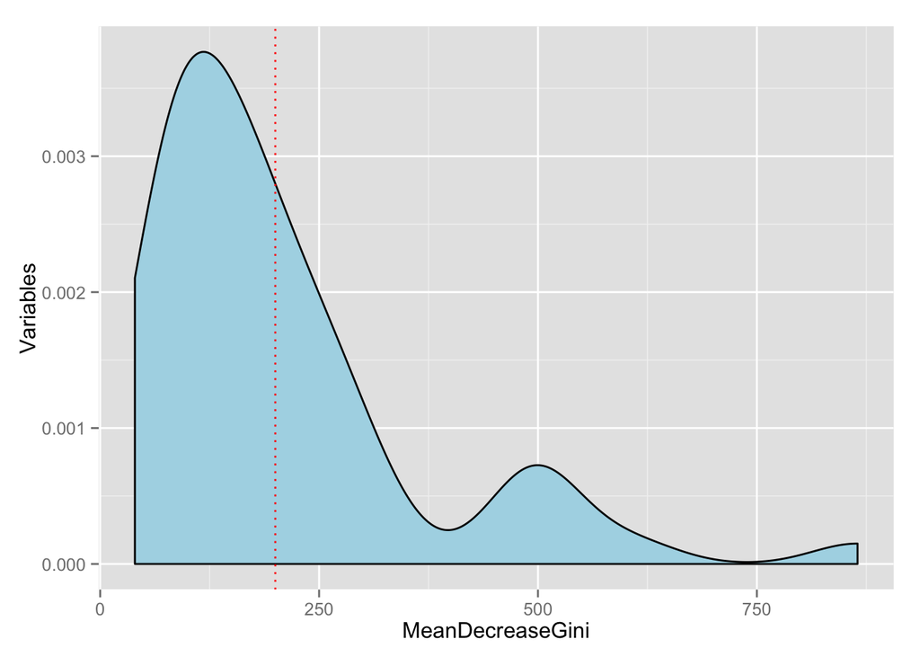

```r
predImportance <- as.data.frame(importance(modFitb))
predImportance %>%
  ggplot(aes(x = MeanDecreaseGini)) +
  geom_density(fill = "lightblue") +
  geom_vline(xintercept = 200, colour = "red", size = 0.5,
             linetype = "dotted") +
  ylab("Variables")
```

```r
importantPreds <- row.names(predImportance)[predImportance$MeanDecreaseGini > 200]
```

Cross validation: I used 10 fold cross validation for calculating the out of sample error. histogram of the fold models and the accuracy of the mean (97%) was a bit lower than the model which uses all the predictors (99%). ———————————————————————————————

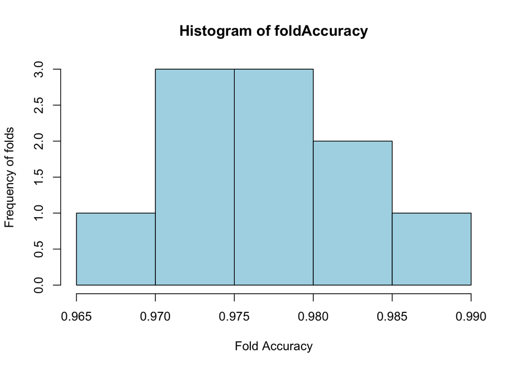

```r
nFolds <- 10
dataFolds <- createFolds(workingTest$classe, k = nFolds)
foldAccuracy <- rep(0, nFolds)

for (fold in 1:nFolds) {
  foldTrain <- workingTest[-dataFolds[[fold]],
                       names(workingTest) %in%
                         c(importantPreds, "classe")]
  foldTest <- workingTest[dataFolds[[fold]], ]

  foldTrainMod <- randomForest(classe ~., data = foldTrain)
  foldTestPred <- predict(foldTrainMod, newdata = foldTest)

  foldAccuracy[fold] <- confusionMatrix(data = foldTestPred,
                                   reference = foldTest$classe)$overall[1]
}
hist(foldAccuracy, xlab = "Fold Accuracy", ylab = "Frequency of folds", col = "lightblue")
```

```r
mean(foldAccuracy)
```

```
## [1] 0.9779114
```

Final model: Using selected 18 predictors, trained the model again using all values (~19,000) for the predictors. This model was tested in the final test set. Summary of the model: Number of trees: 500 No. of variables tried at each split: 4

```r
set.seed(2334)
finalTrain <- checkTrain[, names(checkTrain) %in%  c(importantPreds, "classe")]
finalModFit<-randomForest(classe ~ ., data = finalTrain)
finalModFit
```

```
##
## Call:
##  randomForest(formula = classe ~ ., data = finalTrain)
##                Type of random forest: classification
##                      Number of trees: 500
## No. of variables tried at each split: 4
##
##         OOB estimate of  error rate: 0.42%
## Confusion matrix:
##      A    B    C    D    E class.error
## A 5574    5    0    0    1 0.001075269
## B   10 3769   18    0    0 0.007374243
## C    0   10 3406    6    0 0.004675628
## D    0    0   17 3197    2 0.005907960
## E    0    2    4    7 3594 0.003604103
```

## Test set run:Running the test set to get predictions for the pml-test.csv and the model predicted all the classes correctly.

```r
set.seed(2334)
realTest<-read.csv("pml-testing.csv")
testPred<-predict(finalModFit, realTest)
testPred
```

```
##  1  2  3  4  5  6  7  8  9 10 11 12 13 14 15 16 17 18 19 20
##  B  A  B  A  A  E  D  B  A  A  B  C  B  A  E  E  A  B  B  B
## Levels: A B C D E
```